# Progress Report: Exploring Corpus Features

Zachary Sharrow

8/18/2019

### Summary

This report summarizes the progress I have made so far in working with the data set provided for the course proejct. It summarizes the decisions made during processing as well as the major features of the data sample. Details on the implementation of my predcitive model and Shiny app have yet to be decided. An appendix with the code used in producing these results is included.

### Data Processing and Cleaning

Due to the size of the original data files provided for this project (> 150MB each) and the memory contstraints of my hardware, I began by creating smaller samples of each file. The sample files contain a number of lines equal to 5% of the original files:

```
## Length of twitter_sample.txt: 111755 lines.
```

```
## Length of blog_sample.txt: 42747 lines.
```

```
## Length of news_sample.txt: 49946 lines.
```

After I am confident in my work, I will repeat all parts of the process with the full data sets.

After creating the samples, I applied a profanity filter using a publically available [list of profanity](https://github.com/RobertJGabriel/Google-profanity-words) (content warning for the link). Any lines detected by the profanity filter were completely removed from the sample; I chose to remove the full line rather than only the profane word because I wanted to avoid training my model on inauthentic examples unlikely to be encountered naturally, which is what the later method would produce. The results of the filtering follow:

```
## Twitter:
```

```
## removed 6252 lines.
```

```
## Blogs:
```

```
## removed 2217 lines.
```

```
## News:
```

```
## removed 566 lines.
```

This process removed about **5%** of each of the twitter and blog samples, and about **1%** of the news sample. This result is consistent with the expectation that twitter and blogs, as informal means of communication, include more cursing than news stories do. More importantly, it indicates that the remove-entire-line strategy I used for profanity filtering should not significantly detract from the amount of data available for training.

### Exploratory data analysis

Following data processing, I used the `quanteda` package to examine some properties of each of the three sources types. The number of tokens (words) per line varies by the source of the data:

```
## Tweets:
## The longest line has 57 words.
## There are 17 one-word lines.
## Line length quantiles:
##   0%  25%  50%  75% 100%
##    1    9   14   22   57
##
##
## Blogs:
## The longest line has 852 words.
## There are 284 one-word lines.
## Line length quantiles:
##   0%  25%  50%  75% 100%
##    1   10   31   66  852
##
##
## News:
## The longest line has 354 words.
## There are 126 one-word lines.
## Line length quantiles:
##   0%  25%  50%  75% 100%
##    1   22   36   51  354
```

This information can also be visualized using a histogram:

[figure not shown]

[figure not shown]

[figure not shown]

Using the full corpus, it’s possible to see the most common words and word pairs:

```
## Most common words (with count):
```

```
##   said   just    one   like    can    get   time    new    now   good
##  14809  14252  13554  12182  11712  10532  10164   9534   8528   8492
##    day   love   know people   back
##   8065   7530   7463   7453   6819
```

```
## Most common word pairs (with count)
```

```
##   of_the   in_the   to_the  for_the   on_the    to_be   at_the  and_the
##    20477    19413    10295     9671     9588     7555     6761     5882
##     in_a with_the     is_a   it_was    for_a from_the   i_have
##     5619     4981     4764     4673     4522     4175     4065
```

This information can be presented visually as a bar graph:

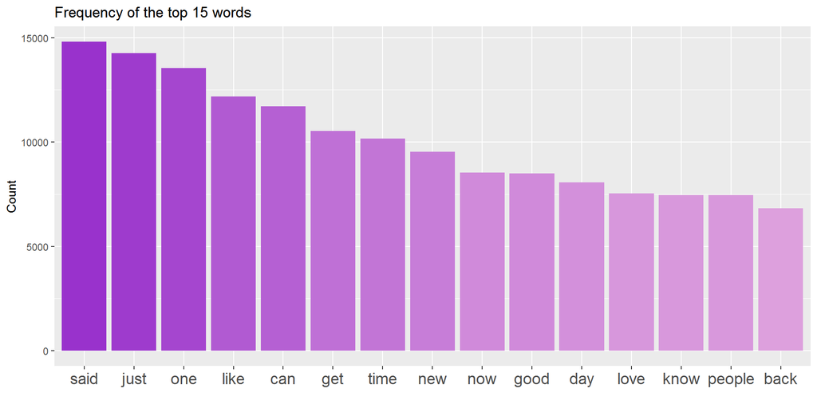

[figure not shown]

It is unsurprising that the most common words are short and carry a great deal of utility and that the most common word pairs tend to be common prepositional and conjunctive phrases. The reader may note that many of the words that appear in the top word pairs do not appear on the list of top individual words; this is due to the way in which the `quanteda` package treats stopwords when generating ngrams. For the purposes of creating a predictive model, it is important not to remove common function words, as they make up a large proportion of everyday language use, so we should be greatly interested in the word pair plot.

### Next steps

The next step in the project is to develop the predictive model and implement it as a Shiny app. I am continuing to independently research the most effective means for creating the model, but in honesty, I must confess that I still feel a bit lost at sea and do not have firm plans at this time. To my peer graders: I would appreciate any guidance you can offer pointing me toward useful resources for accomplishing this.

Thank you for reading!

### Appendix (code)

**Generating samples**

```r
## CREATING THE SAMPLES

## Set seed for reproducibility
set.seed(1180)

## Read in the files to be sampled
twitter <<- readLines("./final/en_US/en_US.twitter.txt", encoding = "UTF-8")
blogs <<- readLines("./final/en_US/en_US.blogs.txt", encoding = "UTF-8")
newses <<- readLines("./final/en_US/en_US.news.txt", encoding = "UTF-8")

## Sample 5 percent of each file
twitter_sample <- sample(twitter, length(twitter) * .05)
blog_sample <- sample(blogs, length(blogs) * .05)
news_sample <- sample(newses, length(newses) * .05)

## Write the samples to a file so they're easier to work with
writeLines(twitter_sample, "./final/en_US/twitter_sample.txt", useBytes = T)
writeLines(blog_sample, "./final/en_US/blog_sample.txt", useBytes = T)
writeLines(news_sample, "./final/en_US/news_sample.txt", useBytes = T)

## Clean up
closeAllConnections()
rm(twitter, newses, blogs, twitter_sample, news_sample, blog_sample)
```

**Profanity filtering**

```r
## Generates the profanity list to be used in filtering

## The main function removes lines containing profanity from a character vector
censorize <- function(file, profanity){
    bad_lines <- sapply(profanity, function(x) grepl(x, file, ignore.case = T))
    bad_lines <- apply(bad_lines, 1, any)
    cat("removed", as.character(sum(bad_lines)), "lines.")
    file[!bad_lines]
}

## Get list from the source
list <- url("https://raw.githubusercontent.com/RobertJGabriel/Google-profanity-words/master/list.txt", open="rt")
bad_words <- readLines(list)

## Add words missing from the default list
bad_words <- c(bad_words, "bullshit")

## Process the list into a regular expression that will find the full words
## but not partial matches
bad_words <- paste(bad_words, collapse = "|", sep = "")
bad_words <- paste0("\\b(", bad_words, ")\\b")

## Read in the samples
twitter <- readLines("./final/en_US/twitter_sample.txt", encoding = "UTF-8")
blogs <- readLines("./final/en_US/blog_sample.txt", encoding = "UTF-8")
news <- readLines("./final/en_US/news_sample.txt", encoding = "UTF-8")

## Filter them
cat("Twitter:")
twitter <- censorize(twitter, bad_words)
cat("Blogs:")
blogs <- censorize(blogs, bad_words)
cat("News:")
news <- censorize(news, bad_words)

## Write the results to a new file
writeLines(twitter, "./final/en_US/twitter_filtered.txt", useBytes = T)
writeLines(blogs, "./final/en_US/blog_filtered.txt", useBytes = T)
writeLines(news, "./final/en_US/news_filtered.txt", useBytes = T)

## Clean up
closeAllConnections()
rm(list, bad_words, twitter, news, blogs)
```

**The main script**

```r
library(quanteda)
library(ggplot2)

## Read in data
twitter <- readLines("./final/en_US/twitter_filtered.txt", encoding = "UTF-8")
blogs <- readLines("./final/en_US/blog_filtered.txt", encoding = "UTF-8")
news <- readLines("./final/en_US/news_filtered.txt", encoding = "UTF-8")


## Concatenate them into the full data set
corpus <- c(twitter, blogs, news)


## Generate quanteda corpuses for each type and the full corpus
twit_corp <- corpus(twitter)
blog_corp <- corpus(blogs)
news_corp <- corpus(news)
full_corp <- corpus(corpus)


## Generate summary statistics about each corpus
twit_tokens <- summary(twit_corp, n = 111755)
blog_tokens <- summary(blog_corp, n = 42747)
news_tokens <- summary(news_corp, n = 49946)
full_tokens <- summary(full_corp, n = 204448)

## Look at the longest and shortest lines
for(i in list(c("Tweets:", twit_tokens), c("Blogs:", blog_tokens), c("News:", news_tokens))){
    cat(as.character(i[1]), "\n")
    cat("The longest line has", as.character(max(i[[4]])), "words.\n")
    cat("There are", as.character(sum(i[[4]] == 1)), "one-word lines.\n")
    cat("Line length quantiles:\n")
    print(quantile(i[[4]]))
    cat("\n\n")
}


## Plot word counts with percentile lines

hist(twit_tokens$Tokens, main = "Frequency of word count per line: Tweets",
     xlab = "Words per line", breaks = "Scott", col = "gainsboro")
abline(v=quantile(twit_tokens$Tokens)[2:4], col = c("dodgerblue", "orangered1", "dodgerblue"),
       lwd = 2, lty = "dashed")
legend(x = "topright", legend = c("25th/75th percentile", "mean"), lty = "dashed",
       lwd = 2, col = c("dodgerblue", "orangered1"), box.lty = 0)

hist(blog_tokens$Tokens, main = "Frequency of word count per line: Blogs",
     xlab = "Words per line", breaks = "Scott", col = "gainsboro")
abline(v=quantile(blog_tokens$Tokens)[2:4], col = c("dodgerblue", "orangered1", "dodgerblue"),
       lwd = 2, lty = "dashed")
legend(x = "topright", legend = c("25th/75th percentile", "mean"), lty = "dashed",
       lwd = 2, col = c("dodgerblue", "orangered1"), box.lty = 0)

hist(news_tokens$Tokens, main = "Frequency of word count per line: News",
     xlab = "Words per line", breaks = "Scott", col = "gainsboro")
abline(v=quantile(news_tokens$Tokens)[2:4], col = c("dodgerblue", "orangered1", "dodgerblue"),
       lwd = 2, lty = "dashed")
legend(x = "topright", legend = c("25th/75th percentile", "mean"), lty = "dashed",
       lwd = 2, col = c("dodgerblue", "orangered1"), box.lty = 0)


## Construct document-features matrices for words and bigrams using the full corpus
dfm1 <- dfm(full_corp, remove = stopwords('english'),
                remove_punct = T)

dfm2 <- dfm(full_corp, remove = stopwords('english'),
            remove_punct = T, ngrams = 2L)

## See the most common features
topfeatures(dfm1, n = 15)
topfeatures(dfm2, n = 15)

## Create data frames from the top features (for ease of plotting)
features1 <- data.frame(word = as.character(names(topfeatures(dfm1, n = 15))),
                        count = unname(topfeatures(dfm1, n = 15)))
features2 <- data.frame(word = as.character(names(topfeatures(dfm2, n = 15))),
                        count = unname(topfeatures(dfm2, n = 15)))

## Plot the top features
plot1 <- ggplot(data = features1, aes(x = reorder(word, -count), y = count)) +
    geom_bar(stat = "identity", aes(fill = count)) +
    scale_fill_gradient(low = "plum", high = "darkorchid") +
    labs(title = "Frequency of the top 15 words", x = "", y = "Count") +
    theme(axis.text.x = element_text(size = 14), legend.position = "none")

plot1

plot2 <- ggplot(data = features2, aes(x = reorder(word, -count), y = count)) +
    geom_bar(stat = "identity", aes(fill = count)) +
    scale_fill_gradient(low = "plum", high = "darkorchid") +
    labs(title = "Frequency of the top 15 bigrams", x = "", y = "Count") +
    theme(axis.text.x = element_text(size = 12), legend.position = "none")

plot2
```

**Technical details**